# Reproducible Research: Peer Assessment 1

This is the first peer assessment for the Johns Hopkins Reproducible Research class on Coursera. Full details of the assignment can be found in the accompanying README.md file in this repository. Essentially, however, we load some data captured from wearable tech and analyse this to answer the following questions:

1. What is mean total number of steps taken per day?
2. What is the average daily activity pattern?
3. Are there differences in activity patterns between weekdays and weekends?

The following is a complete breakdown of the steps taken to perform this analysis, along with any relevant code, code output, plots and the results.

## Loading and preprocessing the data

The first step in our analysis is to make sure we’ve got the raw data! The raw data was included in the repository when we forked this, but just in case, the code below will download/extract the raw data when and if necessary.

```r
# Download the activity.zip file if we don't already have this
dataUrl <- "https://d396qusza40orc.cloudfront.net/repdata%2Fdata%2Factivity.zip"
zipFile <- "./activity.zip"
if (!file.exists(zipFile)) {
    download.file(dataUrl, zipFile, method="curl", mode = "wb")
}

# Extract the zip file if necessary
dataFile <- "./activity.csv"
if (!file.exists(dataFile)) {
    unzip(zipFile)
}
```

Then we load the activity data into a data frame tbl and assign this to the `activity` variable.

```r
library(dplyr)
library(ggplot2)
library(reshape2)
library(lattice)

activity <- tbl_df(read.csv(dataFile))
```

Now we’re ready to perform some data analysis!

## What is mean total number of steps taken per day?

For this part of the anhalysis we ignore NA values. We start by creating a histogram of the total number of steps taken each day.

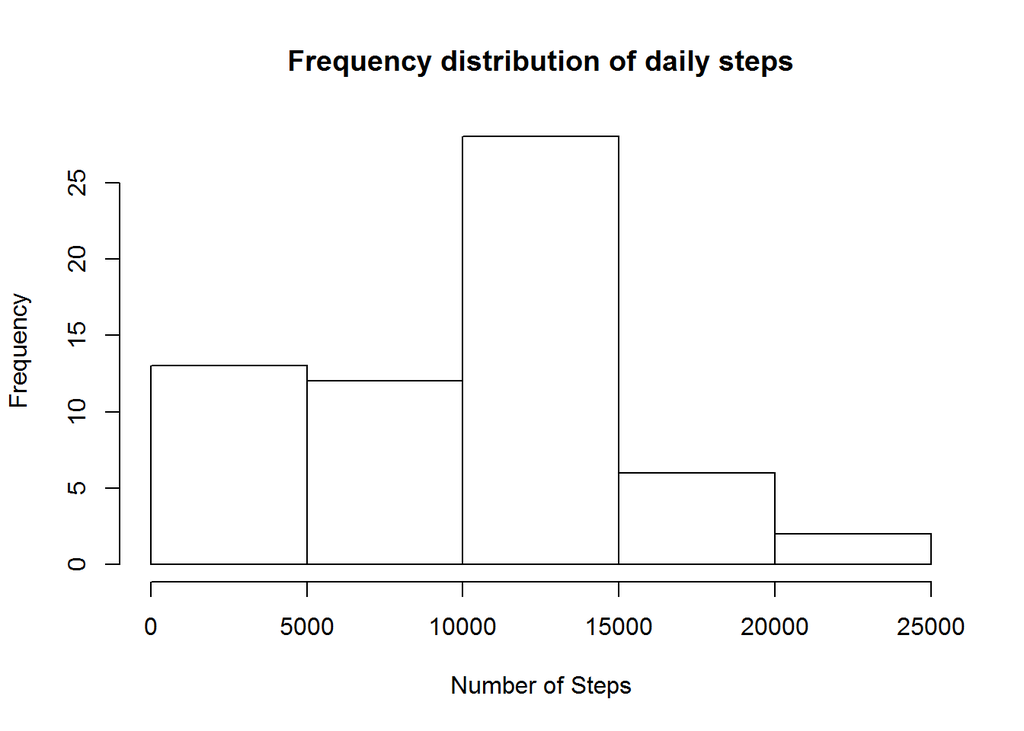

```r
# Create a daily summary of the activity data
daily <- activity %>%
    group_by(date) %>%
    summarise(steps=sum(steps, na.rm = T))

# Now plot a histogram showing the frequency with which various different step
# counts occur
hist(daily$steps,
     main="Frequency distribution of daily steps",
     xlab = "Number of Steps"
     )
```

Now we calculate the mean and median total number of steps taken per day.

```r
daily_mean <- mean(daily$steps)
daily_median <- median(daily$steps)
message(sprintf(
    "Mean daily steps: %.2f\nMedian daily steps: %d", daily_mean, daily_median
))
```

```
## Mean daily steps: 9354.23
## Median daily steps: 10395
```

## What is the average daily activity pattern?

In this part of the assignment we try to see daily walking patterns so we look at the average number of steps taken during any part/interval of the day, over the course of the whole experiment.

We start by grouping the data appropriately. Then we make a time series plot (i.e. type = “l”) of the 5-minute interval (x-axis) and the average number of steps taken, averaged across all days (y-axis).

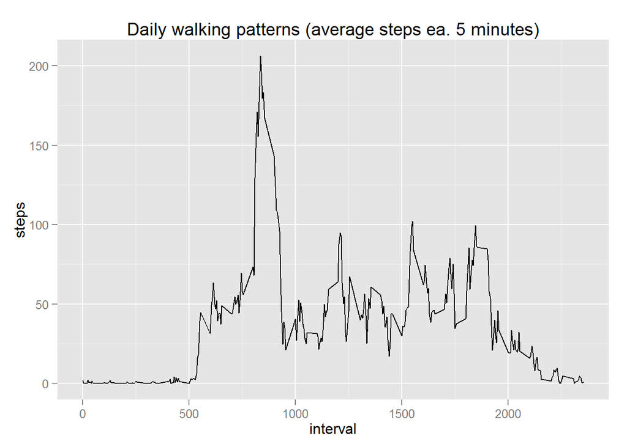

```r
# Group the activity data by interval and summarise average daily activity
# during that interval over the course of the experiment
by_interval <- activity %>%
    group_by(interval) %>%
    summarise(steps=mean(steps, na.rm = T))

# Make a quick line plot of the average daily activity
qplot(interval, steps, data=by_interval,
      geom="line",
      main = "Daily walking patterns (average steps ea. 5 minutes)"
      )
```

Then we calculate the **most active** part of the day, as defined by the 5-minute interval, with the maximum average number of steps across all of the days in the experiment.

```r
peak_interval <- by_interval[which.max(by_interval$steps),]
message(sprintf(
    "Peak activity of %.2f steps during interval %d",
    peak_interval$steps,
    peak_interval$interval
    ))
```

```
## Peak activity of 206.17 steps during interval 835
```

## Imputing missing values

In this part of the assignment we identify periods with missing data and try to impute values for those periods.

We start by calculating the total number of missing values in the dataset (i.e. the total number of rows with NAs).

```r
partial_rows <- sum(!complete.cases(activity))
message(sprintf("%d rows are incomplete", partial_rows))
```

```
## 2304 rows are incomplete
```

Now we implute values for those rows simply by taking the average value for the corresponding 5-minute time interval and create a new dataset (`imputed) that is equal to the original activity dataset, only with the missing data filled in.

```r
imputed <- left_join(activity, by_interval, by="interval")
imputed[is.na(imputed$steps.x),1] <- imputed[is.na(imputed$steps.x),"steps.y"]
```

Now we make a histogram of the total number of steps taken each day and calculate the mean/median total number of steps taken per day using the imputed data.

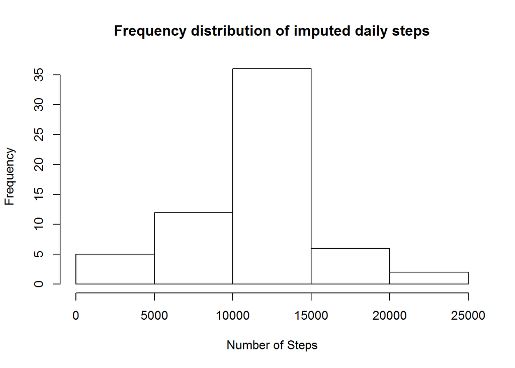

```r
# Create a daily summary of the activity data
daily_imputed <- imputed %>%
    group_by(date) %>%
    summarise(steps=sum(steps.x))

# Now plot a histogram showing the frequency with which various different step
# counts occur
hist(daily_imputed$steps,
     main="Frequency distribution of imputed daily steps",
     xlab = "Number of Steps"
     )
```

```r
imputed_daily_mean <- mean(daily_imputed$steps)
imputed_daily_median <- median(daily_imputed$steps)
message(sprintf(
    "Mean imputed daily steps: %.2f\nMedian imputed daily steps: %.2f",
    imputed_daily_mean,
    imputed_daily_median
))
```

```
## Mean imputed daily steps: 10766.19
## Median imputed daily steps: 10766.19
```

Now we plot the imputed frequency distribution side by side with the original frequency distribution to see the impact of imputing missing data on the estimates of the total daily number of steps.

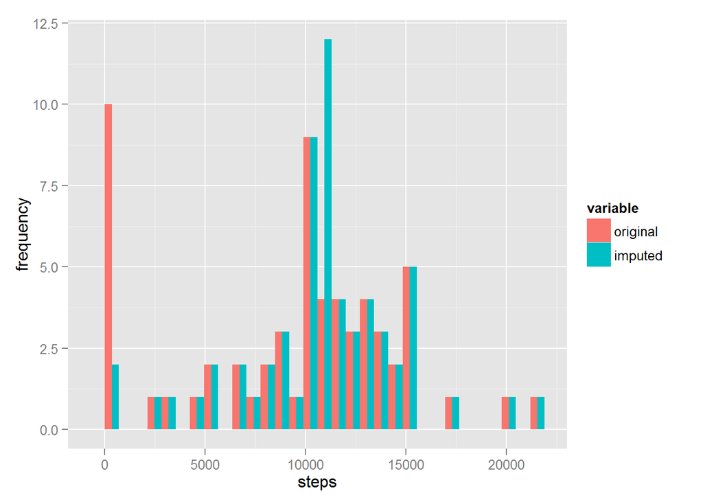

```r
# Collect the original and imputed data together in the same dataset
imputed_impact <- inner_join(daily, daily_imputed, by="date") %>%
    select(original=steps.x, imputed=steps.y)
# Now plot the two side by side
ggplot(
    melt(imputed_impact),
    aes(value, fill = variable)
    ) +
    xlab("steps") +
    ylab("frequency") +
    geom_histogram(position = "dodge")
```

As you might expect, by imputing values for missing values we substantially reduce the number of days in which we have very little data and (simply because of the way we performed the imputation) we substantially increase the frequency of “mean” daily steps. The end result is that the imputed data looks a bit more normally distributed than the original data.

## Are there differences in activity patterns between weekdays and weekends?

For this part of the assignment we separate out activity on weekdays vs weekends and then plot the results side by side, to guage the difference. *Note* that we use the imputed data for this analysis (i.e. there are no NA values).

For this part the weekdays() function may be of some help here. Use the dataset with the filled-in missing values for this part.

We start by creating a new factor variable `day_type` in the dataset with two levels: 1. `weekday` and 2. `weekend`

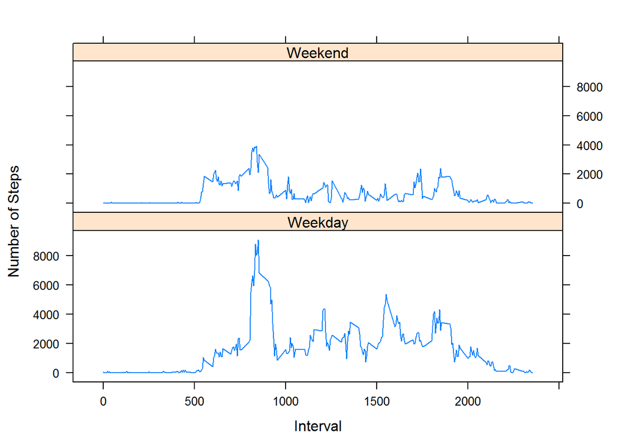

```r
imputed$day <- weekdays(as.POSIXct.Date(imputed$date))
imputed$day_type <- ifelse(imputed$day %in% c("Saturday", "Sunday"), "Weekend", "Weekday")
work <- imputed %>%
    group_by(day_type, interval) %>%
    summarise(steps = sum(steps.x))
xyplot(steps ~ interval | day_type,
       data = work,
       layout = c(1, 2),
       xlab="Interval",
       ylab="Number of Steps",
       panel = function(...) {
            panel.xyplot(..., type = "l")
       }
       )
```